# Klassifizierung

2023-01-16

```r
library(stringr)
library(tidyverse)
```

# Klassifizierung und Gruppenvergleiche

## Klassifizierung

Eine häufige Fragestellung der Datenanalyse ist, einen neuen bisher nicht gesehen Datensatz einer bestimmten Klasse zuzuweisen, ihn damit zu klassifizieren. Wenn Sie jemals einen Naturführer benutzt haben, um eine Pflanze, einen Vogel oder ein Pilz zu bestimmen, haben sie versucht, den Organismus anhand bestimmter Eigenschaften, die sich meist aufs Aussehen beziehen, einer bestimmten Art zuzuweisen. In der Datenanalyse geschieht dies analog.

Es gibt sehr viele verschiedene Ansätze, wie man etwas klassifizieren kann. Hier sind nur ein paar Beispiele für verschiedene Algorithmen, die verschiedene Ansätze verfolgen:

- Nach Ähnlichkeit
  - kNN
- Nach Wahrscheinlichkeit
  - Logistische Regression
  - Naive Bayes
- Nach Entfernung
  - Discriminant analysis
  - Support Vector Machine (SVM)
- Nach Regeln
  - Entscheidungsbäume
- Kombinationen
  - Bagging
  - Boosting

## Beispiel

Wir betrachten als Beispiel den ‘adult’ datensatz, den Sie [hier](https://archive.ics.uci.edu/ml/machine-learning-databases/adult/) herunterladen können. Uns interessiert vorrangig die adult.data Datei. Eine Beschreibung des Datesatzes finden sie in der adult.names-Datei. Zum Datensatz gehört noch die adult.test-Datei, mit der man den trainierten Algorithmus testen könnte. Wir machen zu Demonstrationszwecken eine eigene Aufsplittung in train/test.

Laden Sie zunächst den adult.data sowie adult.test Datensatz. Im adult.test müssen sie noch vorher manuell die erste Zeile (|1x3 Cross validator) entfernen:

```r
adult.data <- read.table("data/adult.data", sep=",")
adult.test <- read.table("data/adult.test", sep=",")

# Wir "kleben" die Daten zusammen, um einen größeren Datensatz zu haben:
adult <- rbind(adult.data, adult.test)
# die Einzeldateien brauchen wir nicht mehr
rm(adult.data, adult.test)

# Die Spaltennamen stammen aus der adult.names Datei
colnms <- c("age",
"workclass",
"fnlwgt",
"education",
"education-num",
"marital-status",
"occupation",
"relationship",
"race",
"sex",
"capital-gain",
"capital-loss",
"hours-per-week",
"native-country",
"class")

# R reagiert allergisch auf "-" in Spaltennamen:
colnms <- make.names(colnms)

# Schließlich weisen wir den Spalten die Namen zu und werfen einen Blick in die Daten:
colnames(adult) <- colnms
rm(colnms)
head(adult)
```

```
##   age         workclass fnlwgt  education education.num      marital.status
## 1  39         State-gov  77516  Bachelors            13       Never-married
## 2  50  Self-emp-not-inc  83311  Bachelors            13  Married-civ-spouse
## 3  38           Private 215646    HS-grad             9            Divorced
## 4  53           Private 234721       11th             7  Married-civ-spouse
## 5  28           Private 338409  Bachelors            13  Married-civ-spouse
## 6  37           Private 284582    Masters            14  Married-civ-spouse
##           occupation   relationship   race     sex capital.gain capital.loss
## 1       Adm-clerical  Not-in-family  White    Male         2174            0
## 2    Exec-managerial        Husband  White    Male            0            0
## 3  Handlers-cleaners  Not-in-family  White    Male            0            0
## 4  Handlers-cleaners        Husband  Black    Male            0            0
## 5     Prof-specialty           Wife  Black  Female            0            0
## 6    Exec-managerial           Wife  White  Female            0            0
##   hours.per.week native.country  class
## 1             40  United-States  <=50K
## 2             13  United-States  <=50K
## 3             40  United-States  <=50K
## 4             40  United-States  <=50K
## 5             40           Cuba  <=50K
## 6             40  United-States  <=50K
```

Der Datensatz enthält jede Menge Leerzeichen sowie “?”, die wir zunächst ersetzen.

```r
adult <- data.frame(lapply(adult, function(x) {
                  gsub("^[[:space:]]", "", x)}))
adult[adult == "?"] <- NA
adult$class <- gsub("[[:punct:]]$","", adult$class)
```

## Aufgabe

Machen Sie sich sonst mit dem Datensatz vertraut. Betreiben sie etwas explorative Datenanalyse, erstellen Sie ein paar Grafiken. Gibt es irgendwelche BEsonderheiten? Ausreißer?

# Gruppenvergleiche

Eine häufige Frage, die Sie sich stellen, wenn sie Klassen mieinander vergleichen, ist, ob diese Klassen sich in irgendetwas voneinander unterscheiden. Gibt es z.B. irgendwelche Parameter, die zu den Klassen erhoben worden waren, kann man fragen, ob sich die Klassen in diesen Parametern unterschieden. Dabei spielt der Datentyp des erhobenen Parameters eine Rolle. Ist es ein kategorischer Typ (z.B. Augenfarbe), so ist das erste Werkzeug der Wahl ein Chi2 Test. Ist der Wert hingegen numerisch, ein t-Test.

## Chi2-Test.

Der Chi-Quadrat-Test testet die Hypothe, ob es einen Zusammenhang zwischen zwei kategorischen Variablen gibt, bzw. ob die beobachtete Verteilung sich signifikant von der zufälligen unterscheidet. Im adult-Datensatz haben wir eine Reihe kategorischer Variablen. Wir können uns z.B. fragen, ob das Gehalt vom Geschlecht abhängig ist. Dazu führen wir den Test in R durch:

```r
chi_res <- chisq.test(x=adult$sex,y=adult$class)
chi_res
```

```
##
##  Pearson's Chi-squared test with Yates' continuity correction
##
## data:  adult$sex and adult$class
## X-squared = 2248.8, df = 1, p-value < 2.2e-16
```

Offenbar gibt es eine Abhängigkeit, da der p-Wert so klein ist. Wir verwerfen die Nullhypothese, dass es KEINE Abhängigkeit zwischen Gehalt und Geschlecht gibt.

Wir können uns noch ansehen, wie die erwartete Verteilung wäre und wie groß die Diskrepanz ist:

```r
wage_discrepancy <- as.data.frame(cbind(chi_res$observed, chi_res$expected))
colnames(wage_discrepancy) <- c(paste0("observed " , colnames(chi_res$observed)),
                                paste0("expected " , colnames(chi_res$expected)))
wage_discrepancy$disprop_over_50K <- wage_discrepancy$`expected >50K` / wage_discrepancy$`observed >50K`
wage_discrepancy
```

```
##        observed <=50K observed >50K expected <=50K expected >50K
## Female          14423          1769       12317.55       3874.45
## Male            22732          9918       24837.45       7812.55
##        disprop_over_50K
## Female        2.1901924
## Male          0.7877142
```

## T-test

Ein t-Test kann verwendet werden, um zu bewerten, ob sich zwei Gruppen in den Mittelwerten eines gemessenen numerischen Parameters voneinander unterscheiden.

Gibt es einen Zusammenhang zwischen Alter und Gehalt? Prüfen Sie zunächst, ob die zu untersuchende Variable normalverteilt ist. Das geschieht am besten durch Betrachtung der Grafiken (Histogramm, Dichteplot, QQ-Plot) oder/und dem Shapiro-Wilk Test.

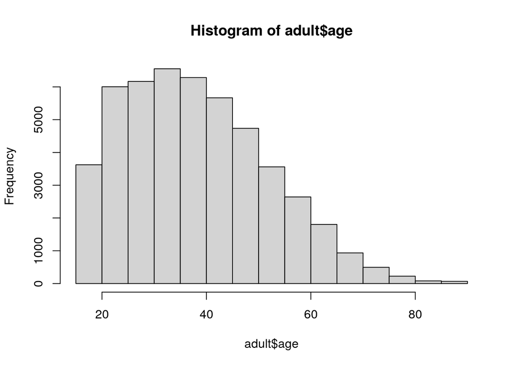

```r
adult$age <- as.numeric(adult$age)
hist(adult$age)
```

Die Kurve ist leicht rechtsschief verteilt. Damit wir sicher gehen, logarithmieren wir die Daten zunächst, bevor wir den T-test durchführen:

```r
adult$age_log <-  log(adult$age)
t.test(age_log ~ class, data = adult, paired=F) # y ist numerisch und x eine binäre Variable
```

```
##
##  Welch Two Sample t-test
##
## data:  age_log by class
## t = -76.313, df = 31005, p-value < 2.2e-16
## alternative hypothesis: true difference in means between group <=50K and group >50K is not equal to 0
## 95 percent confidence interval:
##  -0.2312723 -0.2196897
## sample estimates:
## mean in group <=50K  mean in group >50K
##            3.536539            3.762020
```

Aufgabe: machen Sie sich die Bedeutung der Beschreibung des t-test outputs klar. Wie verhält sich das Einkommen bezüglich der Klasse?

```
2. Klassifikation: Supervised Machine learning (Random Forest, kNN)
3. Machine learning Zyklus (train-test)
```